# ERN from EF bias

Hannah, 4/18/2017

**Major changes: Changed models to cross-classfied models (grouping variables are subject and electrode, where electrode is *not* nested within subject.**

Data from previously processed EEG files from CU and MU were used. Before I got them, the following was done:

1. CNT file was merged with dat file to add response latency and accuracy information to CNT file
2. CNT was re-referenced to average mastoids reference
3. Blinks were corrected for
4. A filter was applied (need to look up the settings for that)
5. Files were response-locked, with an epoch of -400 to 500

I subsequently:

1. Baseline corrected EEG files (using a baseline of -400 to -200)
2. Performed an automatic artifact rejected procedure (trials with +- 75 uV were rejected, only using 9 electrodes of interest as the criteria)

Trials were included if:  
1) The RT was between 200 and 500 ms  
2) A response was made (i.e., no miss trials)  
3) The trial wasn’t rejected in artifact rejection procedure

The following subjects were excluded:  
- 1040 (doesn’t have full number of trials)  
- 2023 (problems with EEG data)  
- 2077 (problems with EEG data)  
- 2089 (problems with EEG data)  
- 2151 (problems with EEG data)  
- 2157 (problems with EEG data)  
- 2181 (problems with EEG data)  
- 2187 (doesn’t have full number of trials)

Each subject did 384 experimental trials (prime-only trials were also included but not in the 384).

FZ, F3, F4, FCZ, FC3, FC4, C3, CZ, C4 (9 electrodes) were included.

**Total sample is 134 subjects, 60 from CU and 74 from MU.**

### 1. Examine correlation between subjects’ ERN mean amplitude and total number of errors

*All conditions together:*

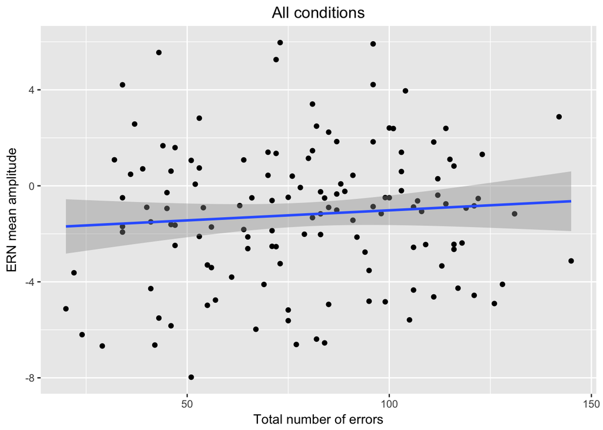

```
##     pearsons.r    pvalue
## cor 0.08327981 0.3387364
```

*By condition separately:*

```
##    condition pearsons.r pvalue
## 1  Black-gun     -0.028  0.745
## 2 Black-tool      0.244  0.004
## 3  White-gun     -0.051  0.559
## 4 White-tool      0.104  0.230
```

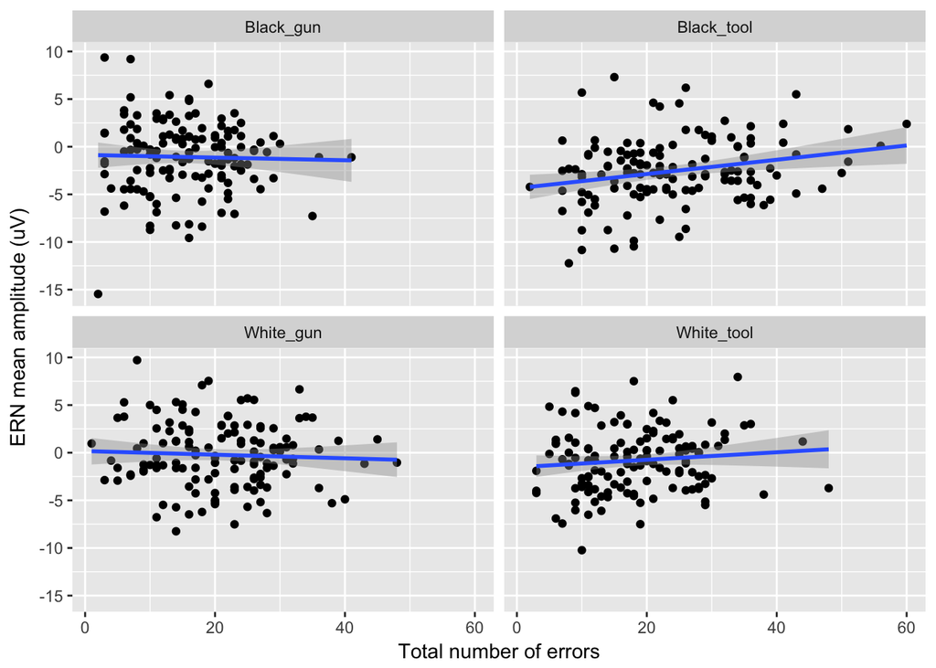

### 2. ERN/CRN grand averages

**Negative is plotted upward.**

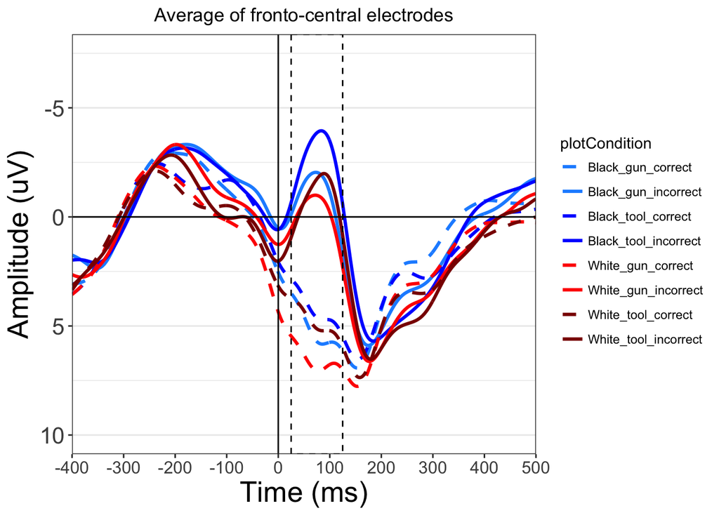

To test the mean amplitude of the ERNs, a model was fitted with Race and Object as predictors, with ERN mean amplitude as the DV (correct trials are not included). The intercept, slopes of Race and Object, and their interaction were allowed to vary by subject. The intercept was allowed to vary by Electrode (*not* nested within Subject).

Race and Object were both effect coded.

**Random effects:**

```
##  Groups    Name            Std.Dev. Corr
##  Subject   (Intercept)     2.87056
##            Race.e          0.95851  -0.106
##            Object.e        1.25871  -0.021 -0.003
##            Race.e:Object.e 0.88495  -0.010 -0.198 -0.049
##  Electrode (Intercept)     1.42298
##  Residual                  7.60126
```

**Fixed effects:**

```
##                 Estimate Std. Error      df t value Pr(>|t|)
## (Intercept)       -1.162      0.536  12.925  -2.167    0.049
## Race.e             0.638      0.088 128.250   7.250    0.000
## Object.e          -0.518      0.113 129.674  -4.591    0.000
## Race.e:Object.e    0.218      0.082 124.040   2.653    0.009
```

### 3. Looking at the ERN over the course of the experiment: Time-on-task

**Slopes and estimates of lines are from the MLM, not fitted with OLS. Negative is plotted downward.**

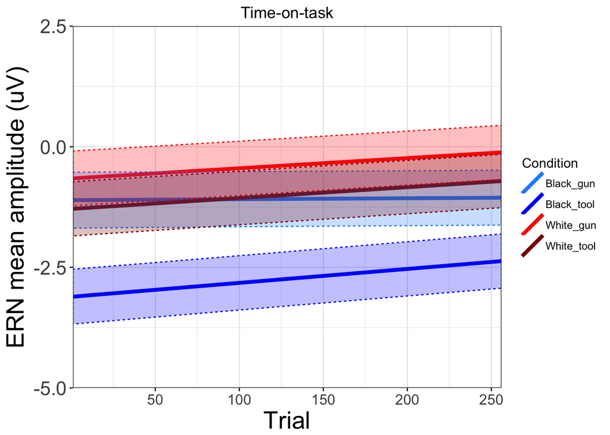

##### Simple slopes

Trial number is rescaled to range from 0 to 10.

```
##   Estimate     SE ci95_lower ci95_upper  Race Object      Color
## 1  0.00775 0.0211    -0.0345      0.050 Black    gun light blue
## 2  0.11112 0.0168     0.0775      0.145 Black   tool  dark blue
## 3  0.08121 0.0182     0.0449      0.118 White    gun  light red
## 4  0.08662 0.0192     0.0482      0.125 White   tool   dark red
```

#### Model output

The intercept, slopes of Race and Object and their interaction are allowed to vary by subject. The intercept is additionally allowed to vary by electrode (*not* nested within subject). *Categorical variables are effect coded.*

Trial is rescaled to range from 0 to 10. Each data point corresponds to ERN mean amplitude following an error, with the error’s original trial number on the x-axis. This spacing maintains time-on-task as the x variable. Fixed effects of Race, Object, and their interaction are estimated at the beginning of the task.

**Random effects:**

```
##  Groups    Name            Std.Dev. Corr
##  Subject   (Intercept)     2.87040
##            Race.e          0.95501  -0.101
##            Object.e        1.25677  -0.022 -0.005
##            Race.e:Object.e 0.88243  -0.004 -0.195 -0.057
##  Electrode (Intercept)     1.42301
##  Residual                  7.59783
```

**Fixed effects:**

```
##                 Estimate Std. Error       df t value Pr(>|t|)
## (Intercept)      -1.5408     0.5385  13.1511 -2.8613   0.0132
## Race.e            0.5678     0.1013 227.0005  5.6060   0.0000
## Object.e         -0.6583     0.1235 186.8736 -5.3300   0.0000
## Race.e:Object.e   0.3434     0.0962 236.0203  3.5689   0.0004
```

```
##                         Estimate Std. Error       df t value Pr(>|t|)
## Trial.s                    0.072      0.009 86995.12   7.582    0.000
## Race.e:Trial.s             0.012      0.009 86925.74   1.295    0.195
## Object.e:Trial.s           0.027      0.009 87009.92   2.877    0.004
## Race.e:Object.e:Trial.s   -0.024      0.009 86878.68  -2.592    0.010
```

### 4. Looking at the ERN over the course of the experiment: Ordered errors

##### - Each error is ordered for each subject (i.e., error #1 for subject 10 and error #1 for subject 20 now have the same x-value, even if it happened on trial 12 for subject 10 and trial 50 for subject 20). Trial-type is ignored when ordering errors.

ICCs were first calculated for subject and electrode.

```
## summary from lme4 is returned
## some computational error has occurred in lmerTest
```

```
## Linear mixed model fit by REML ['lmerMod']
## Formula: MeanAmp ~ (1 | Subject) + (1 | Electrode)
##    Data: trialOrderDat
##
## REML criterion at convergence: 606710.3
##
## Scaled residuals:
##     Min      1Q  Median      3Q     Max
## -7.1012 -0.6377  0.0057  0.6325  6.6469
##
## Random effects:
##  Groups    Name        Variance Std.Dev.
##  Subject   (Intercept)  8.289   2.879
##  Electrode (Intercept)  2.025   1.423
##  Residual              61.041   7.813
## Number of obs: 87212, groups:  Subject, 134; Electrode, 9
##
## Fixed effects:
##             Estimate Std. Error t value
## (Intercept)  -1.1929     0.5363  -2.224
```

The ICC associated with *subject* is 0.1161657.  
The ICC associated with *electrode* is 0.0283792.

**Slopes and estimates of lines are from the MLM, not fitted with OLS. Negative is plotted downward.**

```
## summary from lme4 is returned
## some computational error has occurred in lmerTest
```

```
## Linear mixed model fit by REML ['lmerMod']
## Formula: MeanAmp ~ (1 | Subject) + (1 | Electrode)
##    Data: sigavg
##
## REML criterion at convergence: 23060.9
##
## Scaled residuals:
##     Min      1Q  Median      3Q     Max
## -4.8861 -0.6349  0.0205  0.6224  4.7042
##
## Random effects:
##  Groups    Name        Variance Std.Dev.
##  Subject   (Intercept) 8.176    2.859
##  Electrode (Intercept) 2.018    1.421
##  Residual              6.880    2.623
## Number of obs: 4724, groups:  Subject, 134; Electrode, 9
##
## Fixed effects:
##             Estimate Std. Error t value
## (Intercept)  -1.1627     0.5354  -2.171
```

The ICC associated with *subject* is 0.4788567.  
The ICC associated with *electrode* is 0.1181914.

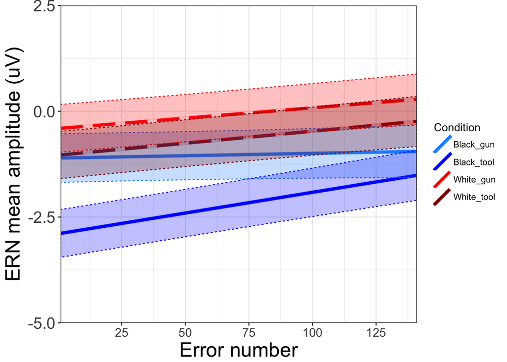

##### Simple slopes

Error order number is rescaled to range from 0 to 10.

```
##   Estimate     SE ci95_lower ci95_upper  Race Object      Color
## 1   0.0158 0.0332    -0.0506     0.0822 Black    gun light blue
## 2   0.1383 0.0258     0.0867     0.1900 Black   tool  dark blue
## 3   0.0690 0.0283     0.0124     0.1257 White    gun  light red
## 4   0.0799 0.0295     0.0208     0.1389 White   tool   dark red
```

#### Model output

The intercept, slopes of Race and Object and their interaction are allowed to vary by subject. Additionally, the intercept is allowed to vary by Electrode. *Categorical variables are effect coded.*

For each subject, error trials are numbered (in order) and rescaled to range from 0 to 10.

**Random effects:**

```
##  Groups    Name            Std.Dev. Corr
##  Subject   (Intercept)     2.86538
##            Race.e          0.95712  -0.101
##            Object.e        1.25039  -0.029 -0.001
##            Race.e:Object.e 0.88300  -0.005 -0.201 -0.044
##  Electrode (Intercept)     1.42302
##  Residual                  7.59974
```

**Fixed effects:**

```
##                 Estimate Std. Error       df t value Pr(>|t|)
## (Intercept)      -1.3614     0.5374  13.0400 -2.5334   0.0249
## Race.e            0.6391     0.0965 186.7713  6.6210   0.0000
## Object.e         -0.6050     0.1190 164.1297 -5.0855   0.0000
## Race.e:Object.e   0.2899     0.0911 190.3586  3.1824   0.0017
```

```
##                              Estimate Std. Error       df t value Pr(>|t|)
## TrialOrder.s                    0.076      0.015 86455.18   5.127    0.000
## Race.e:TrialOrder.s            -0.001      0.015 61586.13  -0.090    0.929
## Object.e:TrialOrder.s           0.033      0.015 75032.17   2.270    0.023
## Race.e:Object.e:TrialOrder.s   -0.028      0.015 56110.16  -1.913    0.056
```

### 5. Looking at the ERN over the course of the experiment: Ordered errors, centered by subject

##### - Each error is ordered for each subject, then centered for each subject

**Slopes and estimates of lines are from the MLM, not fitted with OLS. Negative is plotted downward.**

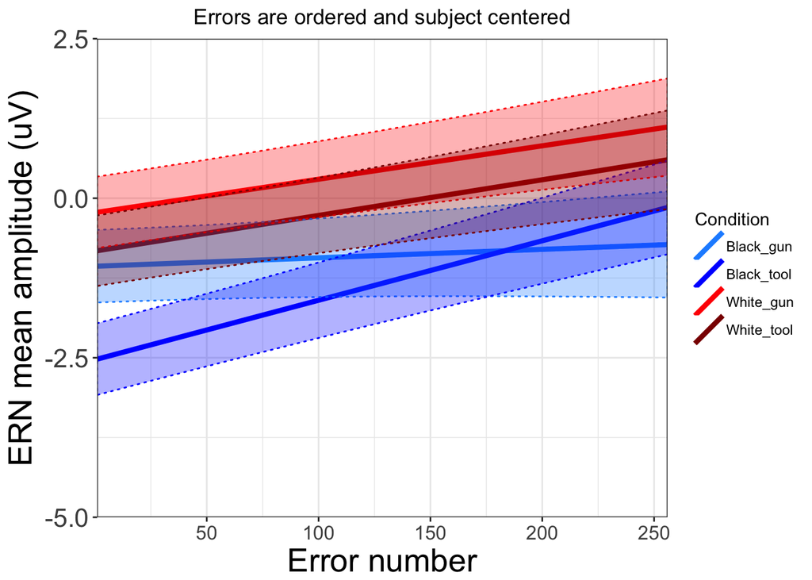

##### Simple slopes

Error order number is rescaled to range from -5 to 5.

```
##   Estimate     SE ci95_lower ci95_upper  Race Object      Color
## 1   0.0188 0.0336    -0.0483     0.0859 Black    gun light blue
## 2   0.1315 0.0260     0.0794     0.1835 Black   tool  dark blue
## 3   0.0739 0.0285     0.0168     0.1309 White    gun  light red
## 4   0.0788 0.0299     0.0191     0.1386 White   tool   dark red
```

#### Model output

The intercept, slopes of Race and Object and their interaction are allowed to vary by subject. The intercept is allowed to vary by electrode. *Categorical variables are effect coded.*

For each subject, error trials are numbered (in order), centered, and rescaled to range from -5 to 5.

**Random effects:**

```
##  Groups    Name            Std.Dev. Corr
##  Subject   (Intercept)     2.87093
##            Race.e          0.95693  -0.103
##            Object.e        1.25753  -0.021 -0.003
##            Race.e:Object.e 0.88474  -0.008 -0.197 -0.052
##  Electrode (Intercept)     1.42302
##  Residual                  7.59973
```

**Fixed effects:**

```
##                 Estimate Std. Error       df t value Pr(>|t|)
## (Intercept)      -1.1630     0.5361  12.9218 -2.1692   0.0493
## Race.e            0.6358     0.0879 128.2830  7.2308   0.0000
## Object.e         -0.5168     0.1128 129.6685 -4.5831   0.0000
## Race.e:Object.e   0.2155     0.0821 124.1305  2.6252   0.0097
```

```
##                                Estimate Std. Error       df t value Pr(>|t|)
## TrialOrder.c.s                    0.076      0.015 86987.02   5.114    0.000
## Race.e:TrialOrder.c.s             0.001      0.015 86930.42   0.041    0.967
## Object.e:TrialOrder.c.s           0.029      0.015 86946.86   1.984    0.047
## Race.e:Object.e:TrialOrder.c.s   -0.027      0.015 86916.94  -1.817    0.069
```

### 6. Looking at the ERN over the course of the experiment: Ordered errors by trial type

##### - Each error is ordered for each subject, separately for each trial type

**Slopes and estimates of lines are from the MLM, not fitted with OLS. Negative is plotted downward.**

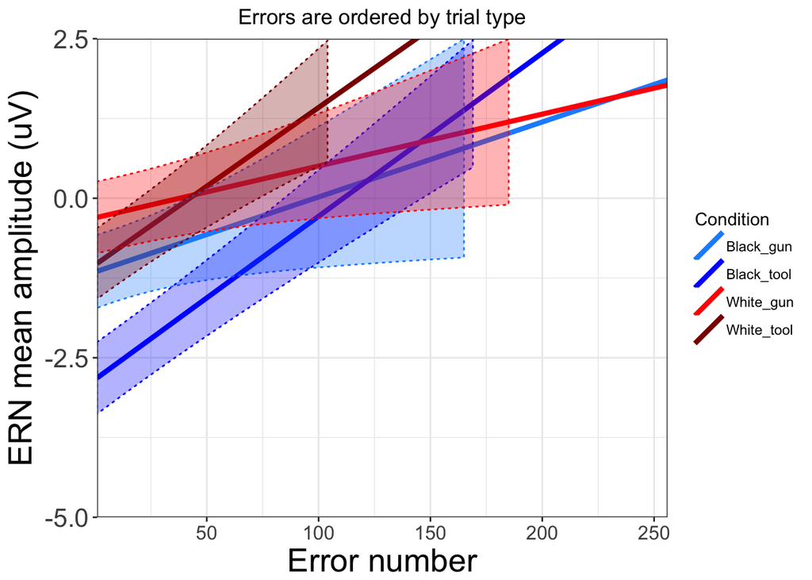

##### Simple slopes

Error order number is rescaled to range from 0 to 10.

```
##   Estimate     SE ci95_lower ci95_upper  Race Object      Color
## 1   0.0694 0.0607    -0.0520      0.191 Black    gun light blue
## 2   0.1510 0.0310     0.0890      0.213 Black   tool  dark blue
## 3   0.0480 0.0396    -0.0312      0.127 White    gun  light red
## 4   0.1456 0.0481     0.0495      0.242 White   tool   dark red
```

#### Model output

The intercept, slopes of Race and Object and their interaction are allowed to vary by subject. The intercept is allowed to vary by electrode. *Categorical variables are effect coded.*

For each subject, error trials are numbered (in order) separately for each trial type and rescaled to range from 0 to 10.

**Random effects:**

```
##  Groups    Name            Std.Dev. Corr
##  Subject   (Intercept)     2.86338
##            Race.e          0.95846  -0.102
##            Object.e        1.24458  -0.034  0.006
##            Race.e:Object.e 0.88777  -0.007 -0.195 -0.045
##  Electrode (Intercept)     1.42301
##  Residual                  7.60001
```

**Fixed effects:**

```
##                 Estimate Std. Error       df t value Pr(>|t|)
## (Intercept)      -1.3382     0.5371  13.0144 -2.4917   0.0270
## Race.e            0.6609     0.0953 177.2619  6.9313   0.0000
## Object.e         -0.6058     0.1175 158.7570 -5.1572   0.0000
## Race.e:Object.e   0.2366     0.0901 178.8324  2.6257   0.0094
```

```
##                                   Estimate Std. Error       df t value Pr(>|t|)
## TrialOrder.type.s                    0.103      0.023 82931.67   4.465    0.000
## Race.e:TrialOrder.type.s            -0.007      0.023 69220.02  -0.290    0.772
## Object.e:TrialOrder.type.s           0.045      0.023 78733.78   1.937    0.053
## Race.e:Object.e:TrialOrder.type.s    0.004      0.023 67046.87   0.175    0.861
```

```
## refitting model(s) with ML (instead of REML)
```

```
## Data: trialOrderDat
## Models:
## ..1: MeanAmp ~ Race * Object * TrialOrder
## object: MeanAmp ~ Race * Object * TrialOrder + (1 | Subject)
##        Df    AIC    BIC  logLik deviance  Chisq Chi Df Pr(>Chisq)
## ..1     9 617932 618016 -308957   617914
## object 10 608208 608302 -304094   608188 9725.9      1  < 2.2e-16 ***
## ---
## Signif. codes:  0 '***' 0.001 '**' 0.01 '*' 0.05 '.' 0.1 ' ' 1
```

```
## refitting model(s) with ML (instead of REML)
```

```
## Data: trialOrderDat
## Models:
## ..1: MeanAmp ~ Race * Object * TrialOrder + (1 | Subject)
## object: MeanAmp ~ Race * Object * TrialOrder + (Race | Subject)
##        Df    AIC    BIC  logLik deviance  Chisq Chi Df Pr(>Chisq)
## ..1    10 608208 608302 -304094   608188
## object 12 607437 607550 -303707   607413 774.82      2  < 2.2e-16 ***
## ---
## Signif. codes:  0 '***' 0.001 '**' 0.01 '*' 0.05 '.' 0.1 ' ' 1
```

```
## refitting model(s) with ML (instead of REML)
```

```
## Data: trialOrderDat
## Models:
## ..1: MeanAmp ~ Race * Object * TrialOrder + (1 | Subject)
## object: MeanAmp ~ Race * Object * TrialOrder + (Object | Subject)
##        Df    AIC    BIC  logLik deviance  Chisq Chi Df Pr(>Chisq)
## ..1    10 608208 608302 -304094   608188
## object 12 606770 606883 -303373   606746 1441.7      2  < 2.2e-16 ***
## ---
## Signif. codes:  0 '***' 0.001 '**' 0.01 '*' 0.05 '.' 0.1 ' ' 1
```

```
## refitting model(s) with ML (instead of REML)
```

```
## Data: trialOrderDat
## Models:
## ..1: MeanAmp ~ Race * Object * TrialOrder + (Race + Object | Subject)
## object: MeanAmp ~ Race * Object * TrialOrder + (Race * Object | Subject)
##        Df    AIC    BIC  logLik deviance  Chisq Chi Df Pr(>Chisq)
## ..1    15 606067 606207 -303018   606037
## object 19 605500 605679 -302731   605462 574.28      4  < 2.2e-16 ***
## ---
## Signif. codes:  0 '***' 0.001 '**' 0.01 '*' 0.05 '.' 0.1 ' ' 1
```

```
## refitting model(s) with ML (instead of REML)
```

```
## Data: trialOrderDat
## Models:
## ..1: MeanAmp ~ Race * Object * TrialOrder
## object: MeanAmp ~ Race * Object * TrialOrder + (1 | Electrode)
##        Df    AIC    BIC  logLik deviance  Chisq Chi Df Pr(>Chisq)
## ..1     9 617932 618016 -308957   617914
## object 10 615739 615833 -307860   615719 2194.8      1  < 2.2e-16 ***
## ---
## Signif. codes:  0 '***' 0.001 '**' 0.01 '*' 0.05 '.' 0.1 ' ' 1
```